# STAT508_DAA5

Ada Lazuli

February 24, 2026

## Front Matter

```r
remove(list = ls())
library(tidyverse)
library(gridExtra)
library(ISLR2)
library(leaps)
library(glmnet)
library(reactable)
library(dplyr)
```

## Problem 1 - Best Subsets Selection Using Indirect Estimate of Test Error

### Part a. - Identify the best model of each size for predicting dis

```r
data("Boston")
regfitBS <- regsubsets(dis ~ ., data = Boston, nvmax = ncol(Boston) - 1)
summary(regfitBS)
```

```
## Subset selection object
## Call: regsubsets.formula(dis ~ ., data = Boston, nvmax = ncol(Boston) -
##     1)
## 12 Variables  (and intercept)
##         Forced in Forced out
## crim        FALSE      FALSE
## zn          FALSE      FALSE
## indus       FALSE      FALSE
## chas        FALSE      FALSE
## nox         FALSE      FALSE
## rm          FALSE      FALSE
## age         FALSE      FALSE
## rad         FALSE      FALSE
## tax         FALSE      FALSE
## ptratio     FALSE      FALSE
## lstat       FALSE      FALSE
## medv        FALSE      FALSE
## 1 subsets of each size up to 12
## Selection Algorithm: exhaustive
##           crim zn  indus chas nox rm  age rad tax ptratio lstat medv
## 1  ( 1 )  " "  " " " "   " "  "*" " " " " " " " " " "     " "   " "
## 2  ( 1 )  " "  "*" " "   " "  "*" " " " " " " " " " "     " "   " "
## 3  ( 1 )  " "  "*" " "   " "  "*" " " "*" " " " " " "     " "   " "
## 4  ( 1 )  " "  "*" " "   " "  "*" " " "*" " " " " " "     " "   "*"
## 5  ( 1 )  " "  "*" "*"   " "  "*" " " "*" " " " " " "     " "   "*"
## 6  ( 1 )  "*"  "*" "*"   " "  "*" " " "*" " " " " " "     " "   "*"
## 7  ( 1 )  "*"  "*" "*"   " "  "*" " " "*" " " " " " "     "*"   "*"
## 8  ( 1 )  "*"  "*" "*"   " "  "*" " " "*" "*" " " " "     "*"   "*"
## 9  ( 1 )  "*"  "*" "*"   "*"  "*" " " "*" "*" " " " "     "*"   "*"
## 10  ( 1 ) "*"  "*" "*"   "*"  "*" " " "*" "*" "*" " "     "*"   "*"
## 11  ( 1 ) "*"  "*" "*"   "*"  "*" " " "*" "*" "*" "*"     "*"   "*"
## 12  ( 1 ) "*"  "*" "*"   "*"  "*" "*" "*" "*" "*" "*"     "*"   "*"
```

### Part b. - Identify the best model using the BIC values

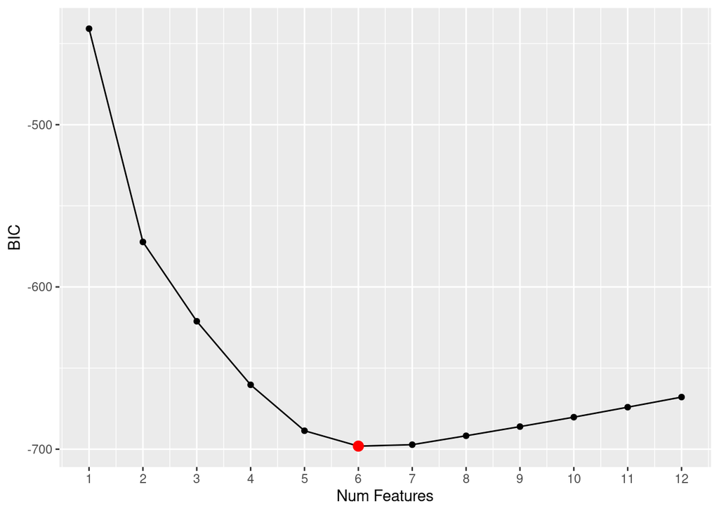

```r
regfitBSsummary <- summary(regfitBS)

optSizeBIC <- which.min(regfitBSsummary$bic)

BICdf <- data.frame(Model = 1:nrow(regfitBSsummary$outmat), BIC = regfitBSsummary$bic)

ggplot(data = BICdf, mapping = aes(x = Model,y = BIC)) + geom_line() + geom_point() +
  scale_x_continuous(breaks = c(1:nrow(regfitBSsummary$outmat))) +
  geom_point(data = BICdf[optSizeBIC, ], color = "red", size = 3) +
  labs(x = "Num Features", y = "BIC")
```

Based on the plot, there is some ambiguity between whether 5 or 6 features would yield a better model. If 5 features are chosen, the BIC is a little worse but the model is easier to interpret. The model with 6 features has a better BIC, but the the additional feature reduces the ambiguity.

Using strictly the best BIC, the 6 features in the model would consist of:

1. `crim`
2. `zn`
3. `indus`
4. `nox`
5. `age`
6. `medv`

### Part c. - If using adjusted r-squared, are the results different? Explain.

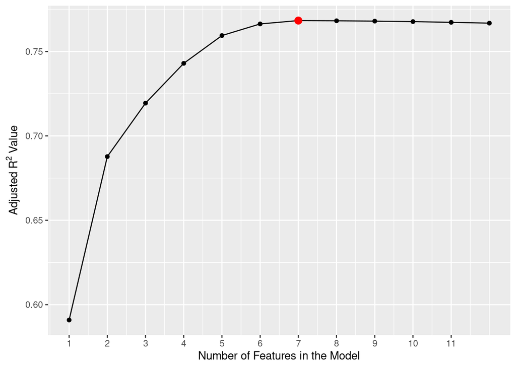

```r
optSizeBIC <- which.min(regfitBSsummary$bic)
optSizeAdjR2 <- which.max(regfitBSsummary$adjr2)
AdjR2df <- data.frame(Model = 1:nrow(regfitBSsummary$outmat),
                    AdjR2 = regfitBSsummary$adjr2)

ggplot(data = AdjR2df, mapping = aes(x = Model, y = AdjR2)) +
  geom_line() +
  geom_point() +
  scale_x_continuous(breaks = c(1:11)) +
  labs(x = "Number of Features in the Model",
       y = expression("Adjusted " * R^2 * " Value")) +
  geom_point(data = AdjR2df[optSizeAdjR2,] , color = "red", size = 3)
```

If $R^2_{adj}$ was used instead, it seems that the model with 7 features is better because it can explain more of the variability in `dis`.

The model with 7 features has all of the features the model chosen earlier, but also includes `lstat`

## Problem 2 - Best Subsets Selection Using Direct Estimate of Test Error

### Part a. - Perform an 80/20 training/validation split using a seed of 123.

```r
set.seed(123)
trainInd <- sample(1:nrow(Boston), floor(0.8*nrow(Boston)), replace = FALSE)

train <- Boston[trainInd, ]
validation <- Boston[ -trainInd,]
```

### Part b. - Use the best subsets approach to identify the best model of each size

```r
regfitBSval <- regsubsets(dis ~ ., data = train, nvmax = ncol(Boston) - 1)
regfitBSsummary <- summary(regfitBSval)

regfitBSsummary
```

```
## Subset selection object
## Call: regsubsets.formula(dis ~ ., data = train, nvmax = ncol(Boston) -
##     1)
## 12 Variables  (and intercept)
##         Forced in Forced out
## crim        FALSE      FALSE
## zn          FALSE      FALSE
## indus       FALSE      FALSE
## chas        FALSE      FALSE
## nox         FALSE      FALSE
## rm          FALSE      FALSE
## age         FALSE      FALSE
## rad         FALSE      FALSE
## tax         FALSE      FALSE
## ptratio     FALSE      FALSE
## lstat       FALSE      FALSE
## medv        FALSE      FALSE
## 1 subsets of each size up to 12
## Selection Algorithm: exhaustive
##           crim zn  indus chas nox rm  age rad tax ptratio lstat medv
## 1  ( 1 )  " "  " " " "   " "  "*" " " " " " " " " " "     " "   " "
## 2  ( 1 )  " "  "*" " "   " "  "*" " " " " " " " " " "     " "   " "
## 3  ( 1 )  " "  "*" " "   " "  "*" " " "*" " " " " " "     " "   " "
## 4  ( 1 )  " "  "*" " "   " "  "*" " " "*" " " " " " "     " "   "*"
## 5  ( 1 )  " "  "*" "*"   " "  "*" " " "*" " " " " " "     " "   "*"
## 6  ( 1 )  "*"  "*" "*"   " "  "*" " " "*" " " " " " "     " "   "*"
## 7  ( 1 )  "*"  "*" "*"   " "  "*" " " "*" " " " " " "     "*"   "*"
## 8  ( 1 )  "*"  "*" "*"   "*"  "*" " " "*" " " " " " "     "*"   "*"
## 9  ( 1 )  "*"  "*" "*"   "*"  "*" " " "*" "*" " " " "     "*"   "*"
## 10  ( 1 ) "*"  "*" "*"   "*"  "*" " " "*" "*" " " "*"     "*"   "*"
## 11  ( 1 ) "*"  "*" "*"   "*"  "*" "*" "*" "*" " " "*"     "*"   "*"
## 12  ( 1 ) "*"  "*" "*"   "*"  "*" "*" "*" "*" "*" "*"     "*"   "*"
```

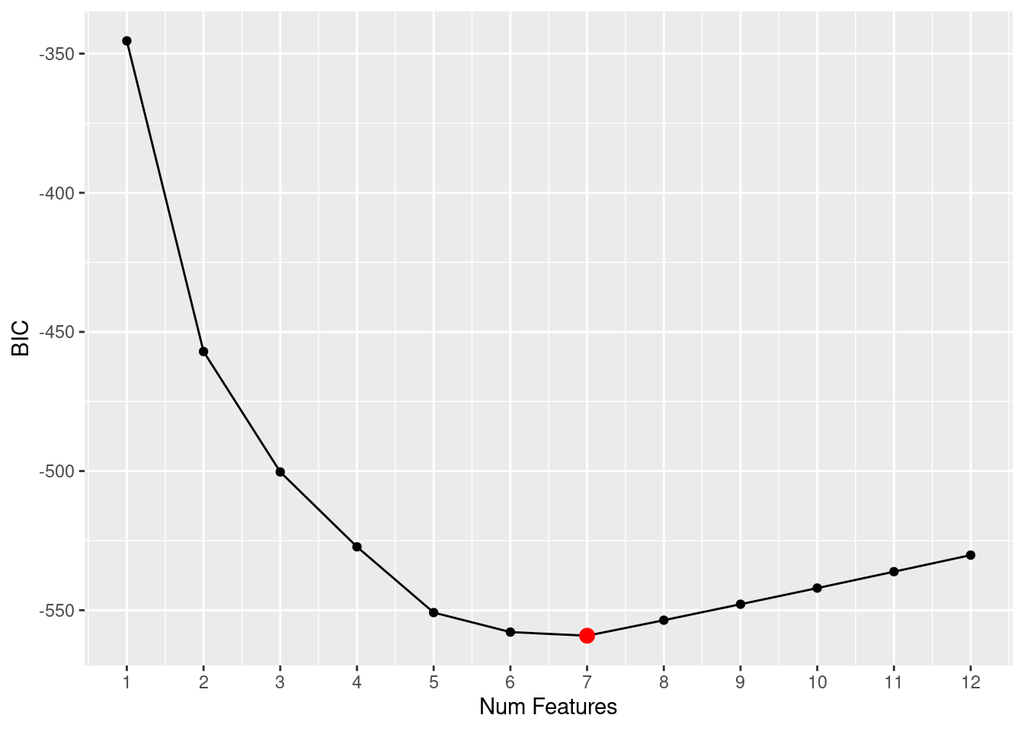

```r
optSizeBIC <- which.min(regfitBSsummary$bic)

BICdf <- data.frame(Model = 1:nrow(regfitBSsummary$outmat), BIC = regfitBSsummary$bic)

ggplot(data = BICdf, mapping = aes(x = Model,y = BIC)) + geom_line() + geom_point() +
  scale_x_continuous(breaks = c(1:nrow(regfitBSsummary$outmat))) +
  geom_point(data = BICdf[optSizeBIC, ], color = "red", size = 3) +
  labs(x = "Num Features", y = "BIC")
```

After training on the training set, there is ambiguity between whether 6 or 7 features should be used. Performance on the validation will be used to make the final decision.

### Part c. - What is the optimal number of variables that should be included based on the validation set MSE?

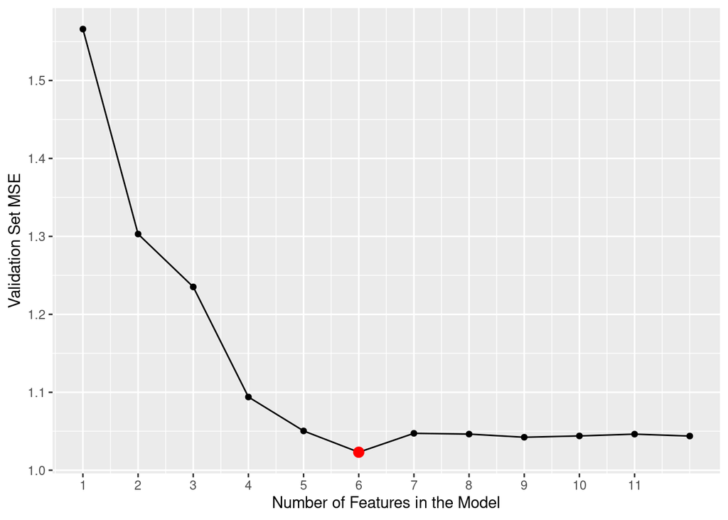

```r
validationMat <- model.matrix(dis ~ ., data = validation)

numModels <- ncol(validationMat) - 1
valMSE <- rep(NA, numModels)

for (i in 1:numModels){
  coefi <- coef(regfitBSval, id = i)
  yhat <- validationMat[, names(coefi)] %*% coefi
  valMSE[i] <- mean((validation$dis - yhat)^2)
}

optSizeVal <- which.min(valMSE)

valMSEdf <- data.frame(Model = 1:numModels,
                       MSE = valMSE)

ggplot(data = valMSEdf, mapping = aes(x = Model, y = MSE)) +
  geom_line() +
  geom_point() +
  scale_x_continuous(breaks = c(1:11)) +
  labs(x = "Number of Features in the Model",
       y = "Validation Set MSE") +
  geom_point(data = valMSEdf[optSizeVal,] , color = "red", size = 3)
```

Based on the results of Validation set MSE, the optimal number of features is 6. The 6 features would still be

1. `crim`
2. `zn`
3. `indus`
4. `nox`
5. `age`
6. `medv`

## Problem 3 - Shrinkage/Regularization Methods

### Part a - Prepare the data. Include an 80/20 training/validation split using a seed of 123

```r
Xmat <- model.matrix(dis ~ ., data = Boston)[, -1]
yvec <- Boston$dis
set.seed(123)
trainInd <- sample(1:nrow(Boston), floor(0.8*nrow(Boston)), replace = FALSE)
set.seed(NULL)
XmatTrain <- Xmat[trainInd,]
XmatVal <- Xmat[-trainInd,]
yvecTrain <- yvec[trainInd]
yvecVal <- yvec[-trainInd]
```

### Part b. - Create plots of the coefficient paths for LASSO and Ridge

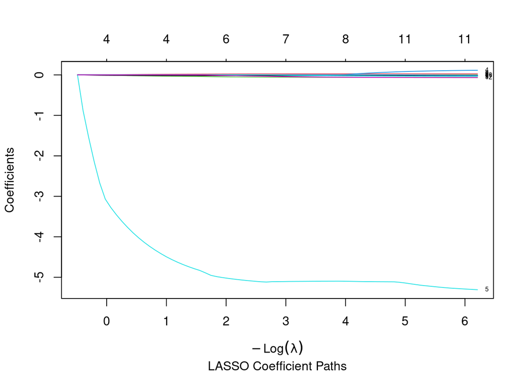

```r
lassoModel <- glmnet(x = XmatTrain, y = yvecTrain,
                    family = "gaussian",
                    alpha = 1,
                    lambda = NULL,
                    standardize = TRUE)

#Create a plot of the coefficient paths
plot(lassoModel, xvar = "lambda", label = TRUE, sub = "LASSO Coefficient Paths")
```

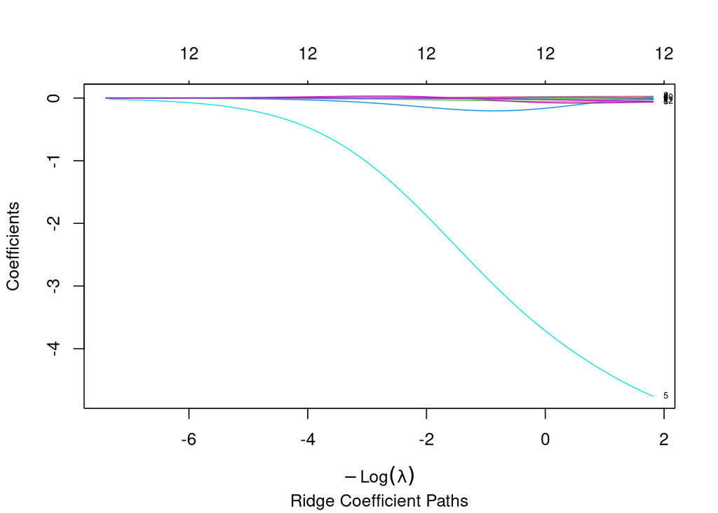

```r
ridgeModel <- glmnet(x = XmatTrain, y = yvecTrain,
                     family = "gaussian",
                     alpha = 0,
                     lambda = NULL,
                     standardize = TRUE)

#Create a plot of the coefficient paths
plot(ridgeModel, xvar = "lambda", label = TRUE, sub = "Ridge Coefficient Paths")
```

### Part c. - For LASSO, choose the optimal value of the tuning parameter, lambda.

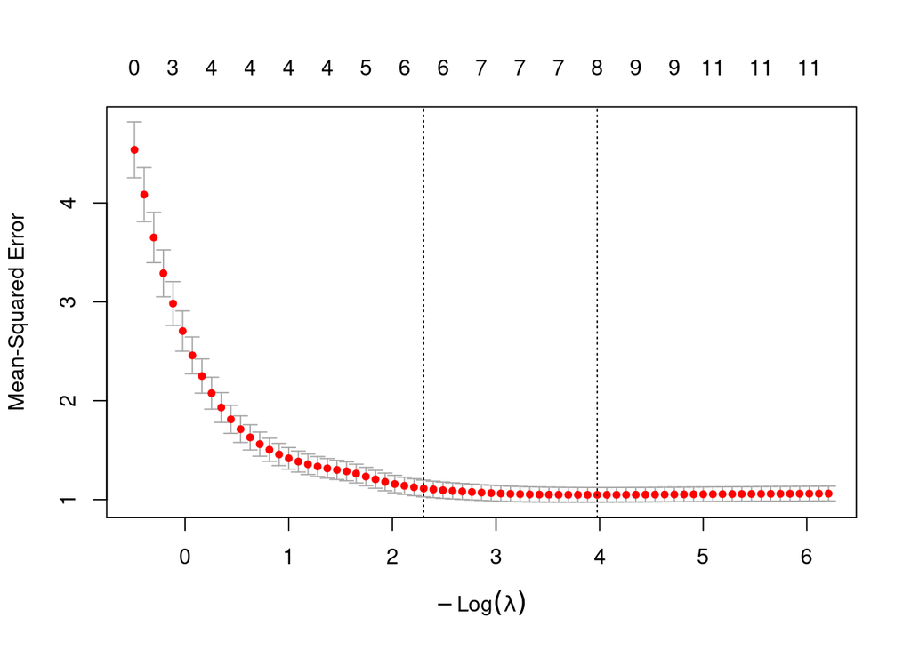

```r
set.seed(123)
lassoCV <- cv.glmnet(x = XmatTrain, y = yvecTrain,
                    family = "gaussian",
                    alpha = 1,
                    lambda = NULL,
                    standardize = TRUE,
                    nfolds = 10)
set.seed(NULL)

#Show the LASSO CV results
plot(lassoCV)
```

There are a couple of methods for choosing lambda. Based on the 1 standard error rule, the optimal value is 0.1000188. The optimal value of lambda based on the min rule is 0.0187417

### Part d. - Using the value of lambda associated with the 1se rule, what variables remain in the LASSO model

```r
coefLam1se <- predict(lassoCV, s = lassoCV$lambda.1se, type = "coefficients")
tempdf <- data.frame(Variable = row.names(coefLam1se), lam1se = as.numeric(coefLam1se))
reactable(tempdf %>% filter(abs(lam1se) > 0), searchable = FALSE, compact = TRUE, striped = TRUE, defaultPageSize = 13, showPageSizeOptions = FALSE)
```

| Variable | lam1se |
| --- | --- |
| (Intercept) | 8.93954829221589 |
| crim | -0.00958117161980222 |
| zn | 0.0240461744273533 |
| indus | -0.0536402983533028 |
| nox | -5.07381895620011 |
| age | -0.0201978347403445 |
| medv | -0.0254276500337186 |

The variables in the lasso model are:

1. `crim`
2. `zn`
3. `indus`
4. `nox`
5. `age`
6. `medv`

```r
lassoYhat <- predict(lassoCV, s = lassoCV$lambda.min, newx = XmatVal)
lassoMSE <-  mean((yvecVal - lassoYhat)^2)
lassoRMSE <- sqrt(lassoMSE)
lassoRMSE
```

```
## [1] 1.021331
```

### Part f. - Compare validation set RMSE values for various methods

```r
set.seed(123) # not asked for, but for repeatability
ridgeCV <- cv.glmnet(x = XmatTrain, y = yvecTrain,
                    family = "gaussian",
                    alpha = 0,
                    lambda = NULL,
                    standardize = TRUE,
                    nfolds = 10)
ridgeYhat <- predict(ridgeCV, s = ridgeCV$lambda.min, newx = XmatVal)
ridgeMSE <-  mean((yvecVal - ridgeYhat)^2)
ridgeRMSE <- sqrt(ridgeMSE)

train <- Boston[trainInd, ]
validation <- Boston[-trainInd,]
lsModel <- lm(dis ~ crim + zn + indus + nox + age + medv, data = train)
lsYhat <- predict(lsModel, newdata = validation)

lsMSE <- mean((validation$dis - lsYhat)^2)
lsRMSE <- sqrt(lsMSE)
data.frame(metric = "Validation RMSE", "Lasso" = lassoRMSE, "Ridge"= ridgeRMSE, "Least Squares" = lsRMSE)
```

```
##            metric    Lasso    Ridge Least.Squares
## 1 Validation RMSE 1.021331 1.028428      1.011486
```

LASSO and Ridge produced very similar RMSE scores on the validation set, with LASSO performing marginally better. The Lease Squares method produced the lowest RMSE score on the validation set.